# Evaluation

Wir laden die fertig berechneten Test-Predictions aus `06_prediction_2-model.ipynb` und analysieren wo das Modell gut und wo es schwächer ist.

**Benchmark:** Stop Mean Baseline MAE = 50.0s | **LightGBM v1 Test MAE = 45.7s** (−4.3s gegenüber Baseline ✅)

## Setup

```python
from zh_tram_flow.notebook import *
import polars as pl
import numpy as np
import pandas as pd
import plotly.express as px
import plotly.graph_objects as go
from pathlib import Path

TRAIN, TEST, lf, lf_all, lf_delay, lf_clean = setup_analysis("06_prediction_3-evaluation")
```

```
✓  wgnd theme activated (matplotlib · seaborn)
```

```
✓  wgnd theme activated (matplotlib · seaborn)
```

```
2026-05-27 09:09:09  INFO      project  06_prediction_3-evaluation started
```

## Load Model & Predictions

```python
pred_path = Path(str(TEST)).parent / "test_predictions.parquet"
pred = pl.read_parquet(pred_path)

print(f"Predictions geladen: {len(pred):,} Zeilen")
print(f"Spalten: {pred.columns}")
pred.head(5)
```

```
Predictions geladen: 29,941,876 Zeilen
Spalten: ['actual', 'predicted', 'line_name', 'stop_name', 'hour', 'month', 'has_rain', 'has_snow', 'has_event']
```

shape: (5, 9)

| actual f32 | predicted f32 | line_name cat | stop_name cat | hour i8 | month i8 | has_rain bool | has_snow bool | has_event bool |
| --- | --- | --- | --- | --- | --- | --- | --- | --- |
| 99.0 | 0.101883 | "2" | "Zürich, Kreuzstrasse" | 5 | 1 | false | false | true |
| 124.0 | 1.643478 | "2" | "Zürich, Feldeggstrasse" | 5 | 1 | false | false | true |
| 16.0 | 1.643478 | "2" | "Zürich, Feldeggstrasse" | 5 | 1 | false | false | true |
| 16.0 | 0.101883 | "2" | "Zürich, Kreuzstrasse" | 5 | 1 | false | false | true |
| 4.0 | 24.418571 | "2" | "Zürich, Zypressenstrasse" | 5 | 1 | false | false | true |

## Metriken — Modell vs. Baseline

```python
def mae(df, actual='actual', predicted='predicted'):
    return (df[actual] - df[predicted]).abs().mean()

def rmse(df, actual='actual', predicted='predicted'):
    return ((df[actual] - df[predicted]) ** 2).mean() ** 0.5

def otp(df, actual='actual', predicted='predicted', threshold=60):
    return ((df[actual] - df[predicted]).abs() <= threshold).mean()

# Modell-Metriken auf Test-Set
model_mae  = mae(pred)
model_rmse = rmse(pred)
model_otp  = otp(pred)

# Baseline-Werte aus 06_prediction_1-baseline.ipynb (Stop Mean)
BASELINE_MAE  = 50.0   # Stop Mean MAE
BASELINE_RMSE = 77.4   # Stop Mean RMSE
BASELINE_OTP  = 0.719  # Stop Mean OTP ±60s

results = pl.DataFrame({
    "":          ["Stop Mean Baseline", "LightGBM v1", "Gewinn"],
    "MAE (s)":   [BASELINE_MAE, round(model_mae, 1), round(BASELINE_MAE - model_mae, 1)],
    "RMSE (s)":  [BASELINE_RMSE, round(model_rmse, 1), round(BASELINE_RMSE - model_rmse, 1)],
    "OTP ±60s":  [f"{BASELINE_OTP:.1%}", f"{model_otp:.1%}", f"+{(model_otp - BASELINE_OTP):.1%}"],
})

show_df(results.to_pandas())
```

|  |  | MAE (s) | RMSE (s) | OTP ±60s |
| --- | --- | --- | --- | --- |
| 0 | Stop Mean Baseline | 50.00 | 77.40 | 71.9% |
| 1 | LightGBM v1 | 45.70 | 75.60 | 77.5% |
| 2 | Gewinn | 4.30 | 1.80 | +5.6% |

## Error Analysis

Wo liegt das Modell daneben? Wir schlüsseln den MAE auf nach:

- **Tageszeit** — Rush-Hour vs. Nacht
- **Linie** — welche Linien sind schwer vorherzusagen?
- **Wetter** — Schnee / Regen / normal
- **Monat** — saisonale Schwächen

```python
# --- MAE nach Stunde ---
mae_hour = (
    pred
    .with_columns((pl.col('actual') - pl.col('predicted')).abs().alias('abs_err'))
    .group_by('hour')
    .agg(pl.col('abs_err').mean().alias('MAE'), pl.len().alias('n'))
    .sort('hour')
)

fig = px.bar(mae_hour.to_pandas(), x='hour', y='MAE',
             title='MAE nach Tageszeit',
             labels={'hour': 'Stunde', 'MAE': 'MAE (s)'})
fig.add_hline(y=model_mae, line_dash='dash', line_color='gray',
              annotation_text=f'Gesamt MAE {model_mae:.1f}s')
fig.show()
show_df(mae_hour.sort('MAE', descending=True).to_pandas())
```

|  | hour | MAE | n |
| --- | --- | --- | --- |
| 0 | 2 | 82.36 | 2969 |
| 1 | 1 | 58.42 | 43943 |
| 2 | 17 | 54.49 | 1711703 |
| 3 | 16 | 53.28 | 1709312 |
| 4 | 18 | 52.79 | 1694478 |
| 5 | 20 | 49.63 | 1537534 |
| 6 | 15 | 47.69 | 1684937 |
| 7 | 21 | 47.36 | 1260073 |
| 8 | 19 | 47.26 | 1660664 |
| 9 | 22 | 46.56 | 1234761 |
| 10 | 8 | 46.50 | 1608924 |
| 11 | 14 | 45.82 | 1678027 |
| 12 | 23 | 44.30 | 1025491 |
| 13 | 9 | 43.66 | 1584551 |
| 14 | 13 | 43.65 | 1685103 |
| 15 | 10 | 42.76 | 1681609 |
| 16 | 7 | 42.65 | 1577620 |
| 17 | 12 | 42.32 | 1692468 |
| 18 | 11 | 40.42 | 1693484 |
| 19 | 0 | 40.37 | 788163 |
| 20 | 6 | 40.04 | 1483656 |
| 21 | 4 | 36.87 | 37048 |
| 22 | 5 | 33.54 | 865358 |

```python
# --- MAE nach Linie ---
mae_line = (
    pred
    .with_columns((pl.col('actual') - pl.col('predicted')).abs().alias('abs_err'))
    .group_by('line_name')
    .agg(pl.col('abs_err').mean().alias('MAE'), pl.len().alias('n'))
    .sort('MAE', descending=True)
)

fig = px.bar(mae_line.to_pandas(), x='line_name', y='MAE',
             title='MAE nach Linie',
             labels={'line_name': 'Linie', 'MAE': 'MAE (s)'})
fig.add_hline(y=model_mae, line_dash='dash', line_color='gray',
              annotation_text=f'Gesamt MAE {model_mae:.1f}s')
fig.show()
show_df(mae_line.to_pandas())
```

|  | line_name | MAE | n |
| --- | --- | --- | --- |
| 0 | 11 | 52.33 | 2834343 |
| 1 | 8 | 51.08 | 2007818 |
| 2 | 15 | 50.50 | 1019990 |
| 3 | 10 | 49.89 | 2266026 |
| 4 | 2 | 46.72 | 2689497 |
| 5 | 4 | 45.99 | 2256185 |
| 6 | 9 | 45.81 | 2839792 |
| 7 | 5 | 45.05 | 954246 |
| 8 | 13 | 44.87 | 2647723 |
| 9 | 14 | 44.63 | 2191741 |
| 10 | 7 | 44.31 | 2683825 |
| 11 | 50 | 42.74 | 142104 |
| 12 | 3 | 42.12 | 1685982 |
| 13 | 51 | 39.55 | 115162 |
| 14 | 17 | 39.26 | 1624041 |
| 15 | 6 | 36.58 | 1145448 |
| 16 | 12 | 34.52 | 837953 |

```python
# --- MAE nach Wetter ---
mae_weather = (
    pred
    .with_columns([
        (pl.col('actual') - pl.col('predicted')).abs().alias('abs_err'),
        pl.when(pl.col('has_snow')).then(pl.lit('Schnee'))
          .when(pl.col('has_rain')).then(pl.lit('Regen'))
          .otherwise(pl.lit('Normal')).alias('weather'),
    ])
    .group_by('weather')
    .agg(pl.col('abs_err').mean().alias('MAE'), pl.len().alias('n'))
    .sort('MAE', descending=True)
)

fig = px.bar(mae_weather.to_pandas(), x='weather', y='MAE',
             title='MAE nach Wetterbedingung',
             labels={'weather': 'Wetter', 'MAE': 'MAE (s)'})
fig.add_hline(y=model_mae, line_dash='dash', line_color='gray',
              annotation_text=f'Gesamt MAE {model_mae:.1f}s')
fig.show()
show_df(mae_weather.to_pandas())
```

|  | weather | MAE | n |
| --- | --- | --- | --- |
| 0 | Schnee | 58.93 | 39920 |
| 1 | Regen | 49.48 | 2699615 |
| 2 | Normal | 45.35 | 27202341 |

```python
# --- MAE nach Monat ---
mae_month = (
    pred
    .with_columns((pl.col('actual') - pl.col('predicted')).abs().alias('abs_err'))
    .group_by('month')
    .agg(pl.col('abs_err').mean().alias('MAE'), pl.len().alias('n'))
    .sort('month')
)

fig = px.bar(mae_month.to_pandas(), x='month', y='MAE',
             title='MAE nach Monat (Test-Jahr 2025)',
             labels={'month': 'Monat', 'MAE': 'MAE (s)'})
fig.add_hline(y=model_mae, line_dash='dash', line_color='gray',
              annotation_text=f'Gesamt MAE {model_mae:.1f}s')
fig.show()
show_df(mae_month.to_pandas())
```

|  | month | MAE | n |
| --- | --- | --- | --- |
| 0 | 1 | 41.81 | 2596478 |
| 1 | 2 | 41.25 | 2310617 |
| 2 | 3 | 44.38 | 2559422 |
| 3 | 4 | 45.38 | 2323347 |
| 4 | 5 | 48.20 | 2540176 |
| 5 | 6 | 49.73 | 2400665 |
| 6 | 7 | 49.48 | 2485490 |
| 7 | 8 | 46.29 | 2468589 |
| 8 | 9 | 47.15 | 2816622 |
| 9 | 10 | 49.59 | 2516937 |
| 10 | 11 | 46.97 | 2469829 |
| 11 | 12 | 38.33 | 2453704 |

## Key Findings — Fehleranalyse

**Rush-Hour ist die stärkste Schwachstelle**

- 16h: 53.3s · 17h: 54.5s · 18h: 52.8s — alle deutlich über Gesamtschnitt (45.7s)
- Beste Stunden: 4–6h mit 33–40s — geringer Verkehr = geringere Varianz

**L11 und L8 schlagen die Baseline nicht**

- L11: 52.3s · L8: 51.1s · L15: 50.5s — alle über Baseline (50.0s)
- Genau die Linien durch K11/K12 — strukturell schwierigste Zonen des Netzes
- Gegenstück: L12 34.5s · L6 36.6s · L17 39.3s — größte Modell-Gewinne

**Schnee überfordert das Modell**

- MAE Schnee 58.9s vs. Normal 45.4s — Differenz +13.5s
- Nur 40k Schnee-Halte im Testjahr 2025 — zu wenig Trainings- und Testdaten für seltene Ereignisse

**Systematischer Optimismus-Bias**

## Verbesserungsmöglichkeiten

**Kurzfristig — gleicher Stack, mehr Signal**

- `prev_stop_delay` als Feature — Delay des Vorgänger-Halts in derselben Fahrt (Kaskadenindikator)
- `stop_sequence` explizit als numerisches Feature — Delay akkumuliert mit Strecke
- Baustellenkalender als binäres Feature — temporäre Streckenstörungen

**Mittelfristig — Modell-Tuning**

- Quantile Regression (`objective="quantile"`) statt MAE — reduziert Optimismus-Bias direkt
- Separate Modelle für L11 / L8 — linienspezifische Muster lernen
- Hyperparameter-Tuning mit Optuna (num_leaves, min_child_samples, learning_rate)

**Längerfristig — alternative Ansätze**

- XGBoost — robuster bei Extremwerten durch andere Baum-Regularisierung
- CatBoost — stärker bei hochkardinalen Kategorien wie `stop_name`
- Sequenzmodell (z.B. LightGBM mit Rolling Features) — explizite Zeitabhängigkeit modellieren

## Feature Importance — Was hat das Modell gelernt?

Hat das Modell dieselben Muster gelernt, die die 55 Findings der Analyse-Phase beschreiben?

Feature Importance (Gain) zeigt, wie viel jedes Feature zur Reduktion des Vorhersagefehlers beiträgt — normalisiert auf 100 %.

`stop_name` und `hour` sollten dominieren (räumlich + temporal stärkste Signale aus Analyse). `has_snow` und `is_holiday` zeigen ob der Wetter- und Event-Effekt gelernt wurde.

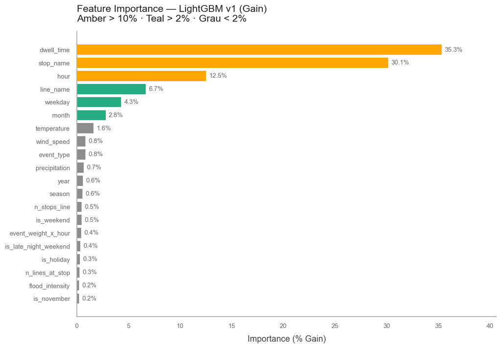

|  | Feature | Gain (%) | Splits |
| --- | --- | --- | --- |
| 0 | dwell_time | 35.31 | 509 |
| 1 | stop_name | 30.14 | 9338 |
| 2 | hour | 12.51 | 4533 |
| 3 | line_name | 6.67 | 4086 |
| 4 | weekday | 4.29 | 2044 |
| 5 | month | 2.79 | 1426 |
| 6 | temperature | 1.61 | 2023 |
| 7 | wind_speed | 0.83 | 1314 |
| 8 | event_type | 0.81 | 682 |
| 9 | precipitation | 0.67 | 488 |
| 10 | year | 0.57 | 481 |
| 11 | season | 0.55 | 431 |
| 12 | n_stops_line | 0.48 | 515 |
| 13 | is_weekend | 0.46 | 128 |
| 14 | event_weight_x_hour | 0.40 | 528 |
| 15 | is_late_night_weekend | 0.36 | 92 |
| 16 | is_holiday | 0.30 | 175 |
| 17 | n_lines_at_stop | 0.26 | 201 |
| 18 | flood_intensity | 0.22 | 216 |
| 19 | is_november | 0.21 | 86 |
| 20 | has_rain | 0.15 | 53 |
| 21 | district_nr | 0.13 | 154 |
| 22 | event_size | 0.10 | 143 |
| 23 | gtfs_year | 0.09 | 72 |
| 24 | event_weight | 0.03 | 30 |
| 25 | has_flood | 0.02 | 23 |
| 26 | is_hot | 0.02 | 23 |
| 27 | has_snow | 0.01 | 24 |
| 28 | has_heavy_rain | 0.00 | 4 |
| 29 | has_event | 0.00 | 0 |
| 30 | is_end_stop | 0.00 | 0 |
| 31 | is_start_stop | 0.00 | 0 |

```python
import lightgbm as lgb
from wgnd.core.theme import mpl_style
from wgnd.core.config import cfg
import matplotlib.pyplot as plt

model_path = Path(str(TEST)).parent.parent / "models" / "lgbm_v1.txt"
model = lgb.Booster(model_file=str(model_path))

# Feature Importance — Gain (wie viel erklärt jedes Feature?)
feat_imp = (
    pd.DataFrame({
        "feature":    model.feature_name(),
        "gain":       model.feature_importance(importance_type="gain"),
        "split":      model.feature_importance(importance_type="split"),
    })
    .assign(pct=lambda df: df["gain"] / df["gain"].sum() * 100)
    .sort_values("pct", ascending=False)
    .reset_index(drop=True)
)

top = feat_imp.head(20).copy()

# Farb-Kodierung: Amber = dominierend (>10%), Teal = relevant (>2%), Grau = Rest
def _color(pct):
    if pct > 10:  return cfg.COLOR_SIGNAL
    if pct > 2:   return cfg.COLOR_POSITIVE
    return cfg.ANNO_REF

colors = [_color(p) for p in top["pct"]]

style = mpl_style()
fig, ax = plt.subplots(figsize=(10, 7))

bars = ax.barh(
    top["feature"][::-1], top["pct"][::-1],
    color=colors[::-1], edgecolor="white", linewidth=0.4,
)
for bar, pct in zip(bars, top["pct"][::-1]):
    ax.text(
        bar.get_width() + 0.3, bar.get_y() + bar.get_height() / 2,
        f"{pct:.1f}%", va="center", fontsize=9,
        color=cfg.CHART_AXIS_TEXT,
    )

ax.set_xlabel("Importance (% Gain)", **style["label"])
ax.set_title(
    "Feature Importance — LightGBM v1 (Gain)\n"
    "Amber > 10% · Teal > 2% · Grau < 2%",
    **style["title"],
)
ax.spines[["top", "right"]].set_visible(False)
ax.spines[["left", "bottom"]].set_color(cfg.CHART_AXIS)
ax.tick_params(colors=cfg.CHART_AXIS_TEXT, labelsize=9)
ax.set_xlim(0, top["pct"].max() * 1.15)
plt.tight_layout()
plt.show()

show_df(
    feat_imp.head(33)
    [["feature", "pct", "split"]]
    .rename(columns={"feature": "Feature", "pct": "Gain (%)", "split": "Splits"})
    .round({"Gain (%)": 2})
    .reset_index(drop=True)
)
```

## Residuals — Systematischer Bias?

Schaut das Modell systematisch zu optimistisch (Vorhersage < Ist) oder zu pessimistisch (Vorhersage > Ist)?

```python
residuals = pred.with_columns(
    (pl.col('actual') - pl.col('predicted')).alias('residual')
)

mbe = residuals['residual'].mean()
print(f"Mean Bias Error (MBE): {mbe:.2f}s")
print(f"  > 0 = Modell unterschätzt Delay (zu optimistisch)")
print(f"  < 0 = Modell überschätzt Delay (zu pessimistisch)")

# Residual-Verteilung
sample = residuals.sample(n=min(50_000, len(residuals)), seed=42)
fig = px.histogram(sample.to_pandas(), x='residual', nbins=100,
                   title='Residual-Verteilung (actual − predicted)',
                   labels={'residual': 'Residual (s)', 'count': 'Anzahl'},
                   range_x=[-300, 300])
fig.add_vline(x=0, line_color='red', line_dash='dash')
fig.add_vline(x=mbe, line_color='orange',
              annotation_text=f'MBE {mbe:.1f}s')
fig.show()
```

```
Mean Bias Error (MBE): 8.32s
  > 0 = Modell unterschätzt Delay (zu optimistisch)
  < 0 = Modell überschätzt Delay (zu pessimistisch)
```

### Predicted vs. Actual — Bias sichtbar gemacht

Hexbin-Dichte (100k Stichprobe): zeigt wo Vorhersagen konzentriert sind. Ideal: alle Punkte auf der gestrichelten **y = x** Linie. Der Bias (+8.3s) ist sichtbar als **Verschiebung nach unten** — Modell sagt systematisch weniger Delay voraus als tatsächlich eintritt.

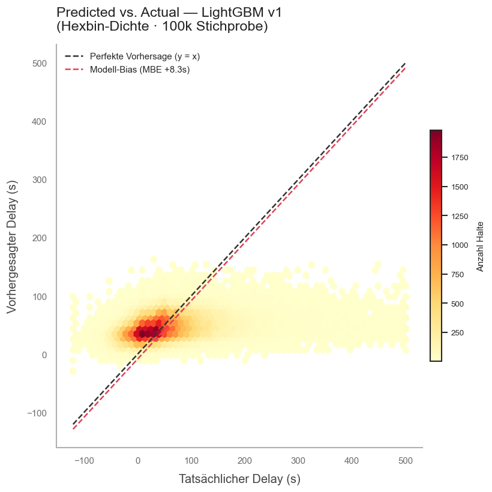

```python
sample = pred.sample(n=100_000, seed=42).to_pandas()

CLIP_LO, CLIP_HI = -120, 500   # sinnvoller Darstellungsbereich (s)

style = mpl_style()
fig, ax = plt.subplots(figsize=(7, 7))

hb = ax.hexbin(
    sample["actual"].clip(CLIP_LO, CLIP_HI),
    sample["predicted"].clip(CLIP_LO, CLIP_HI),
    gridsize=60, cmap="YlOrRd", mincnt=1,
    extent=[CLIP_LO, CLIP_HI, CLIP_LO, CLIP_HI],
)

# Perfekte Vorhersage-Linie (y = x)
ax.plot([CLIP_LO, CLIP_HI], [CLIP_LO, CLIP_HI],
        color="#333333", lw=1.5, ls="--", label="Perfekte Vorhersage (y = x)", zorder=5)

# Bias-Linie (verschoben um MBE)
mbe_val = float(residuals["residual"].mean())
ax.plot([CLIP_LO, CLIP_HI], [CLIP_LO - mbe_val, CLIP_HI - mbe_val],
        color=cfg.COLOR_NEGATIVE, lw=1.5, ls="--",
        label=f"Modell-Bias (MBE +{mbe_val:.1f}s)", zorder=4)

ax.set_xlabel("Tatsächlicher Delay (s)", **style["label"])
ax.set_ylabel("Vorhergesagter Delay (s)", **style["label"])
ax.set_title("Predicted vs. Actual — LightGBM v1\n(Hexbin-Dichte · 100k Stichprobe)", **style["title"])
ax.legend(fontsize=9, frameon=False, loc="upper left")
ax.spines[["top", "right"]].set_visible(False)
ax.spines[["left", "bottom"]].set_color(cfg.CHART_AXIS)
ax.tick_params(colors=cfg.CHART_AXIS_TEXT, labelsize=9)

cb = fig.colorbar(hb, ax=ax, fraction=0.03, pad=0.02)
cb.set_label("Anzahl Halte", fontsize=9)
cb.ax.tick_params(labelsize=8)

plt.tight_layout()
plt.show()
```

## Konkrete Vorhersage — Das Szenario aus dem Overview

Live-Demonstration: Eine einzelne Eingabe → eine Vorhersage. Input exakt wie im Szenario aus `06_prediction_0-overview`.

```python
import lightgbm as lgb

model_path = Path(str(TEST)).parent.parent / "models" / "lgbm_v1.txt"
model = lgb.Booster(model_file=str(model_path))

# Szenario aus 06_prediction_0-overview:
# Dienstag 17:00 · Haltestelle Paradeplatz · Linie 11 · leichter Regen · kein Event
scenario = pd.DataFrame([{
    "line_name":          "11",
    "stop_name":          "Paradeplatz",
    "district_nr":        1,
    "temperature":        14.0,
    "precipitation":      1.5,
    "wind_speed":         12.0,
    "flood_intensity":    0,
    "event_type":         "none",
    "event_size":         0,
    "hour":               17,
    "weekday":            1,
    "month":              6,
    "year":               2025,
    "season":             "summer",
    "is_weekend":         False,
    "is_november":        False,
    "gtfs_year":          "j25",
    "has_rain":           True,
    "has_heavy_rain":     False,
    "has_snow":           False,
    "has_flood":          False,
    "is_hot":             False,
    "is_holiday":         False,
    "has_event":          False,
    "event_weight":       0,
    "dwell_time":         0,
    "n_lines_at_stop":    14,
    "n_stops_line":       30,
    "is_start_stop":      False,
    "is_end_stop":        False,
    "event_weight_x_hour": 0,
    "is_late_night_weekend": False,
}])

# Kategoriale Spalten setzen
for col in ['line_name', 'stop_name', 'event_type', 'season', 'gtfs_year']:
    scenario[col] = scenario[col].astype('category')

pred_val = model.predict(scenario)[0]
print(f"Szenario: Dienstag 17:00 · Paradeplatz · Linie 11 · leichter Regen")
print(f"Vorhergesagter Delay: {pred_val:.0f}s ({pred_val/60:.1f} min)")
```

```
Szenario: Dienstag 17:00 · Paradeplatz · Linie 11 · leichter Regen
Vorhergesagter Delay: 52s (0.9 min)
```

## Fazit

```python
fazit = pl.DataFrame({
    "Modell":       ["Grand Mean", "Hour Mean", "Line Mean", "Stop Mean", "LightGBM v1"],
    "MAE (s)":      [50.6, 50.5, 50.4, 50.0, round(model_mae, 1)],
    "vs. Baseline": ["—", "—", "—", "Benchmark", f"-{BASELINE_MAE - model_mae:.1f}s ✅"],
})

show_df(fazit.to_pandas())

print()
print("Fazit:")
print(f"  LightGBM v1 erreicht MAE {model_mae:.1f}s auf dem Test-Set (2025).")
print(f"  Das Modell schlägt die Stop-Mean-Baseline ({BASELINE_MAE}s) um {BASELINE_MAE - model_mae:.1f}s.")
print(f"  Stärkste Schwäche: Rush-Hour und Schneetage (siehe Error Analysis).")
```

|  | Modell | MAE (s) | vs. Baseline |
| --- | --- | --- | --- |
| 0 | Grand Mean | 50.60 | — |
| 1 | Hour Mean | 50.50 | — |
| 2 | Line Mean | 50.40 | — |
| 3 | Stop Mean | 50.00 | Benchmark |
| 4 | LightGBM v1 | 45.70 | -4.3s ✅ |

```
Fazit:
  LightGBM v1 erreicht MAE 45.7s auf dem Test-Set (2025).
  Das Modell schlägt die Stop-Mean-Baseline (50.0s) um 4.3s.
  Stärkste Schwäche: Rush-Hour und Schneetage (siehe Error Analysis).
```

## Abschluss — Was das Modell zeigt

**Das Modell funktioniert — und es ist ehrlich über seine Grenzen.**

**Was funktioniert**

- Baseline geschlagen: −4.3s MAE auf einem kompletten Testjahr (2025) mit 30 Mio. Halts
- Gute Generalisierung: Test MAE (45.7s) besser als Val MAE (49.0s) — kein Overfitting
- Linien ohne strukturelle Anomalie (L12, L6, L17): Gewinn bis zu −15s gegenüber Baseline
- Live-Vorhersage: Di 17h · Paradeplatz · L11 · Regen → **52s** — plausibel, direkt nutzbar

**Was schwierig bleibt**

- Rush-Hour (16–18h): Delay-Spitzen zu variabel für verlässliche Vorhersage
- L11 / L8: Zu hohe Varianz in den Problemzonen — Baseline nicht geschlagen
- Seltene Ereignisse (Schnee, Extremnacht): zu wenig Daten für robuste Schätzungen
- Systematischer Bias: +8.3s Unterschätzung — Modell ist zu optimistisch

**Was das für die Praxis bedeutet**

- Das Modell eignet sich gut für **typische Situationen** (80% der Halte): normale Tage, bekannte Linien
- Für **Extremlagen** (Rush-Hour, Schnee, L11) braucht es mehr Signal: Cascade-Features, separate Modelle
- Die Fehleranalyse zeigt klar **wo als nächstes** anzusetzen ist — das ist kein Zufallsfund, sondern direkte Ableitung aus den 55 Findings der Analyse-Phase

**Nächste Schritte**

- `prev_stop_delay` Feature hinzufügen → LightGBM v2
- Interaktives Vorhersage-Tool: Haltestelle + Linie + Uhrzeit + Wetter → Delay in Sekunden